# STAT 312R - HW5

Vinayak Mathur

20st April 2022

### Question 2 8.S10

During the 1999 and 2000 baseball seasons, there was much speculation that the unusually large number of home runs hit was due at least in part to a livelier ball. One way to test the “liveliness” of a baseball is to launch the ball at a vertical surface with a known velocity VL and measure the ratio of the outgoing velocity VO of the ball to VL. The ratio $R = VO/VL$ is called the coefficient of restitution. Following are measurements of the coefficient of restitution for 40 randomly selected base- balls. The balls were thrown from a pitching machine at an oak surface.

(0.6248, 0.6237, 0.6118, 0.6159, 0.6298, 0.6192, 0.6520, 0.6368, 0.6220, 0.6151, 0.6121, 0.6548, 0.6226, 0.6280, 0.6096, 0.6300, 0.6107, 0.6392, 0.6230, 0.6131, 0.6223, 0.6297, 0.6435, 0.5978, 0.6351, 0.6275, 0.6261, 0.6262, 0.6262, 0.6314, 0.6128, 0.6403, 0.6521, 0.6049, 0.6170, 0.6134, 0.6310, 0.6065, 0.6214, 0.6141)  
a. Is there evidence to support the assumption that the  
coefficient of restitution is normally distributed?

```r
coeffs <- c(0.6248, 0.6237, 0.6118, 0.6159, 0.6298, 0.6192, 0.6520, 0.6368, 0.6220, 0.6151, 0.6121, 0.6548, 0.6226, 0.6280, 0.6096, 0.6300, 0.6107, 0.6392, 0.6230, 0.6131, 0.6223, 0.6297, 0.6435, 0.5978, 0.6351, 0.6275, 0.6261, 0.6262, 0.6262, 0.6314, 0.6128, 0.6403, 0.6521, 0.6049, 0.6170, 0.6134, 0.6310, 0.6065, 0.6214, 0.6141)

library(qualityTools)
```

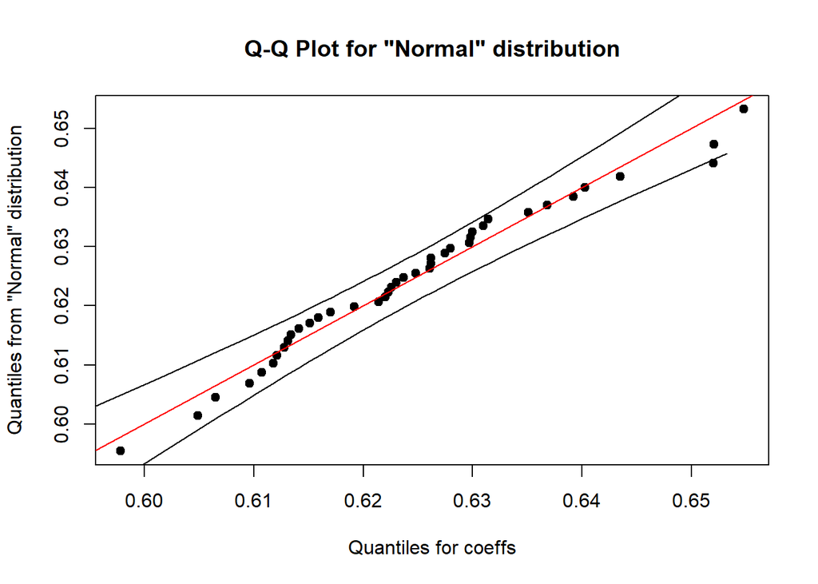

```r
qqPlot(coeffs, "Normal")
```

2. Find a 99% CI on the mean coefficient of restitution.

```r
n <- length(coeffs)
xbar <- mean(coeffs)
s <- sd(coeffs)
t <- qt(p = .005, df = n - 1)
margin <- t * s / sqrt(n)
lower <- xbar + margin
upper <- xbar - margin

print(lower)
```

```
## [1] 0.6187462
```

```r
print(upper)
```

```
## [1] 0.6299288
```

Ans) $0.6187462 \leq \mu \leq 0.6299288$

3. Find a 99% prediction interval on the coefficient of  
   restitution for the next baseball that will be tested.

```r
margin <- t * s * sqrt(n + 1) / sqrt(n)
lower <- xbar + margin
upper <- xbar - margin

print(lower)
```

```
## [1] 0.5885355
```

```r
print(upper)
```

```
## [1] 0.6601395
```

Ans) $0.0.5885355 \leq \mu \leq 0.6601395$

### Question 4 9.2.8

Supercavitation is a propulsion technology for undersea vehicles that can greatly increase their speed. It occurs above approximately 50 meters per second when pressure drops sufficiently to allow the water to dissociate into water vapor, forming a gas bubble behind the vehicle. When the gas bubble completely encloses the vehicle, supercavitation is said to occur. Eight tests were conducted on a scale model of an undersea vehicle in a towing basin with the average observed speed $x = 102.2$ meters per second. Assume that speed is normally distributed with known standard deviation $\sigma = 4$ meters per second.

1. Test the hypothesis $H0: \mu = 100$ versus $H1: \mu < 100$ using $α = 0.05$.

```r
mu <- 100
xbar <- 102.2
sig <- 4
n <- 8

z0 <- (xbar - mu) / (sig / sqrt(n))

za <- 1.65
# we reject H0 if z0<-za
res <- z0 < (-za)
print(res)
```

```
## [1] FALSE
```

Ans) We do not reject $H_0$ and reject $H_1$

2. What is the P-value for the test in part (a)?

```r
2 * pnorm(-abs(z0))
```

```
## [1] 0.1197949
```

3. Compute the power of the test if the true mean speed is as low as 95 meters per second.

```r
mu2 <- 95
z0 <- (mu2 - mu) / (sig / sqrt(n))
print(z0)
```

```
## [1] -3.535534
```

```r
print(1 - pnorm(-za - z0))
```

```
## [1] 0.0296789
```

ans) 0.0296789

### Question 5 9.3.11

Given ASU female student height data in inches: (62, 64, 61, 67, 65, 68, 61, 65, 60, 65, 64, 63, 59, 68, 64, 66, 68, 69, 65, 67, 62, 66, 68, 67, 66, 65, 69, 65, 69, 65, 67, 67, 65, 63, 64, 67, 65)

$H_0: \mu \geq 65$  
$H_1: \mu < 65$

1. Can you support a claim that the mean height of female engineering students at ASU is at least 65 inches? Use $\alpha = 0.05$. Find the P-value.

```r
heightData <- c(62, 64, 61, 67, 65, 68, 61, 65, 60, 65, 64, 63, 59, 68, 64, 66, 68, 69, 65, 67, 62, 66, 68, 67, 66, 65, 69, 65, 69, 65, 67, 67, 65, 63, 64, 67, 65)


mu <- 65

t.test(heightData, mu = mu)
```

```
##
##  One Sample t-test
##
## data:  heightData
## t = 0.3877, df = 36, p-value = 0.7005
## alternative hypothesis: true mean is not equal to 65
## 95 percent confidence interval:
##  64.31388 66.01044
## sample estimates:
## mean of x
##  65.16216
```

```r
qt(0.05/2, 36, lower.tail = FALSE)
```

```
## [1] 2.028094
```

2. Check the normality assumption.

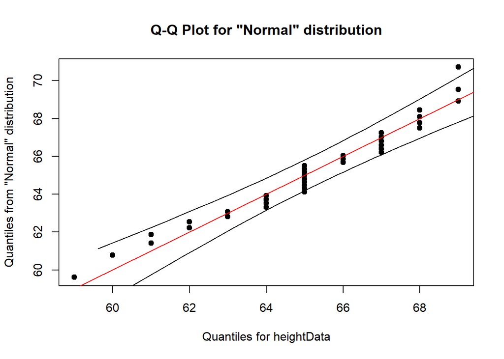

```r
qqPlot(heightData, "Normal")
```

```r
shapiro.test(heightData)
```

```
##
##  Shapiro-Wilk normality test
##
## data:  heightData
## W = 0.95118, p-value = 0.1053
```

ans) Since p-value = 0.1053 > 0.05, $H_0$ is accepted and the distribution is concluded to be normally distributed.

3. Compute the power of the test if the true mean height is 68 inches.

```r
t.test(heightData, mu = 68)
```

```
##
##  One Sample t-test
##
## data:  heightData
## t = -6.7848, df = 36, p-value = 6.299e-08
## alternative hypothesis: true mean is not equal to 68
## 95 percent confidence interval:
##  64.31388 66.01044
## sample estimates:
## mean of x
##  65.16216
```

```r
1-6.299e-08
```

```
## [1] 0.9999999
```

ans) p-value = 1